# Results

2025-04-24

Return to Model README: [README](https://github.com/benjhodgson/metapop_capacity_matrix/blob/main/README.md)

# 1 Exploring Metapopulation Capacity

## 1.1 The independent effects of habitat cover on metapopulation capacity

Experimental Design: [The independent effects of habitat cover on metapopulation capacity - Methods](https://github.com/benjhodgson/metapop_capacity_matrix/blob/main/Documentation/Experimental-Design.md#the-independent-effects-of-habitat-cover-on-metapopulation-capacity)

Changing the size of habitat patches, without changing the distance between the habitat patches gives the following relationship between metapopulation capacity and habitat cover:

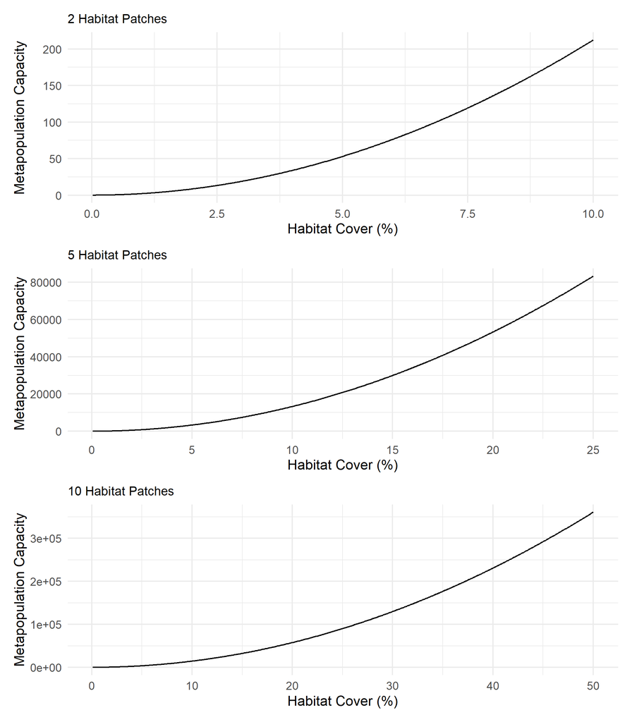

The log of metapopulation capacity plotted against habitat cover gives the following results:

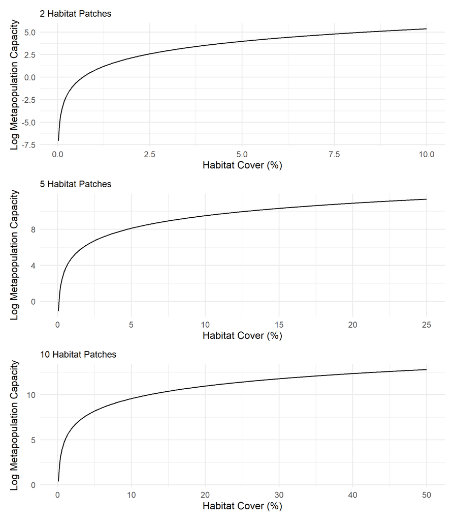

## 1.2 The independent effects of inter-patch distance on metapopulation capacity

Scaling the dispersal matrix whilst keeping the habitat area constant gives the following relationship between metapopulation capacity and mean distance between habitat patches.

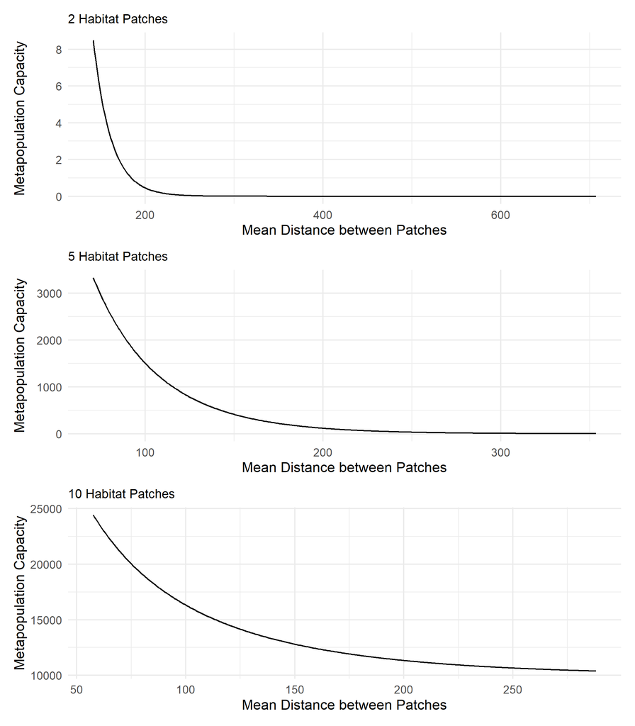

The log of metapopulation capacity plotted against mean distance between patches gives the following results:

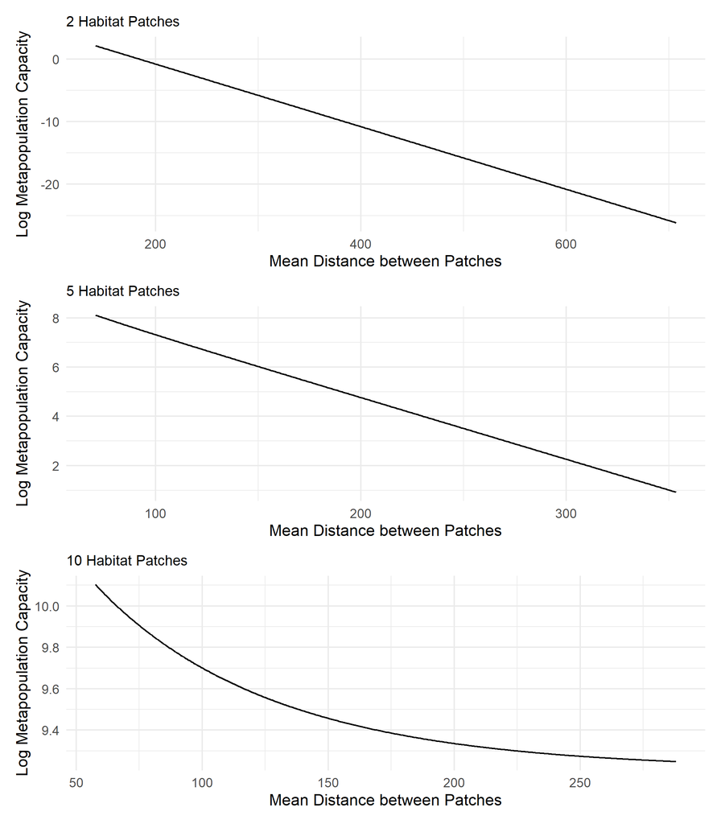

## 1.3 The effects of habitat configuration on patch distances and areas

Experimental Design: [The effects of habitat configuration on patch distances and areas - Methods](https://github.com/benjhodgson/metapop_capacity_matrix/blob/main/Documentation/Experimental-Design.md#the-effects-of-habitat-configuration-on-patch-distances-and-areas)

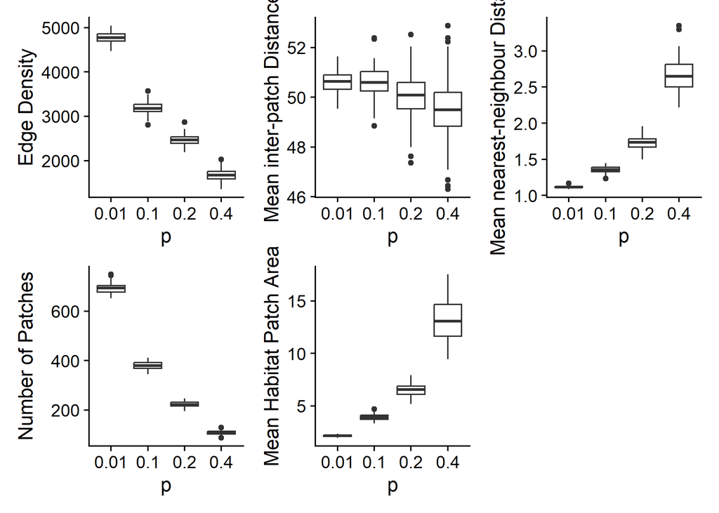

## 1.4 The effects of habitat cover on patch distances and areas

Experimental Design: [The effects of habitat cover on patch distances and areas - Methods](https://github.com/benjhodgson/metapop_capacity_matrix/blob/main/Documentation/Experimental-Design.md#the-effects-of-habitat-cover-on-patch-distances-and-areas)

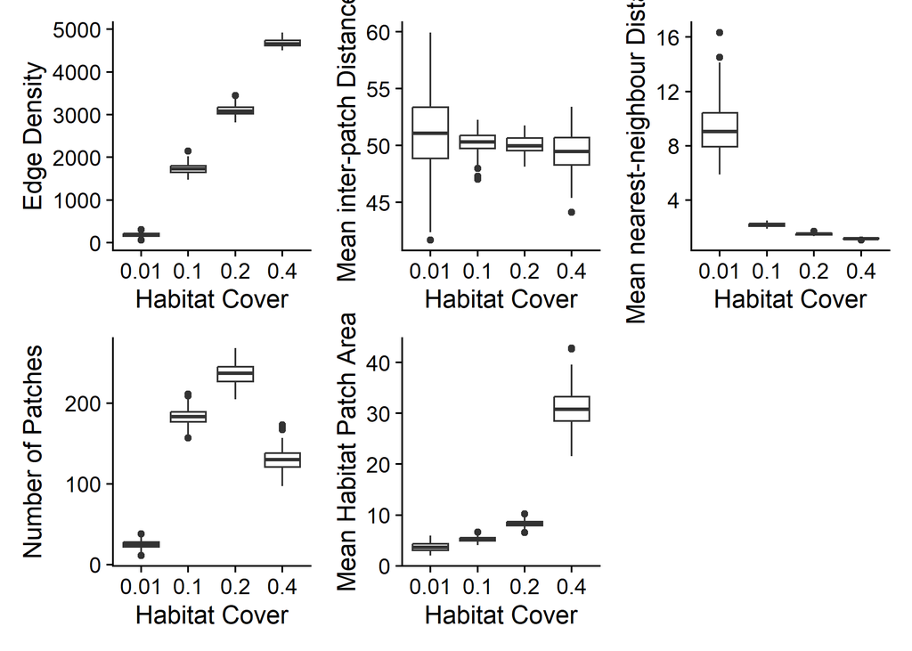

# 2 The effect of Matrix Quality on Metapopulation Capacity and Persistence

## 2.1 The effect of Matrix Quality on Metapopulation Capacity

### 2.1.1 Landscapes with high levels of habitat aggregation

High levels of habitat aggregation with a maximum dispersal distance increase of 50%

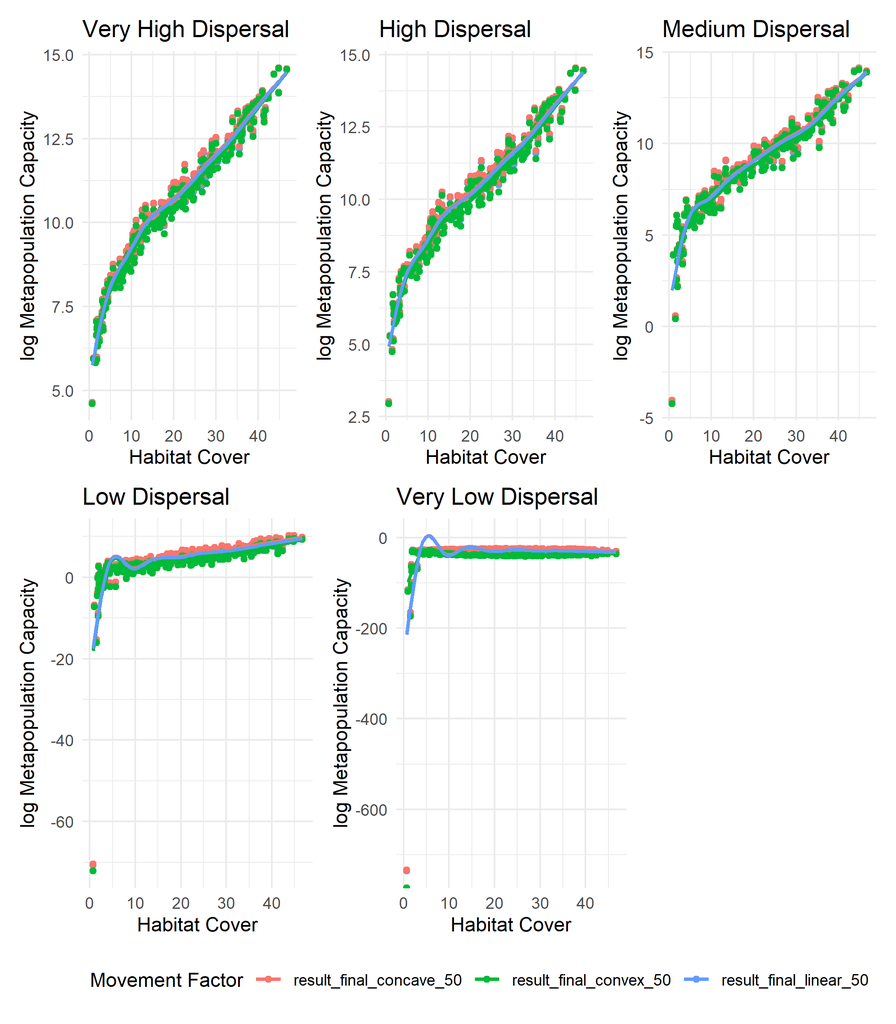

High levels of habitat aggregation with a maximum dispersal distance increase of 500%

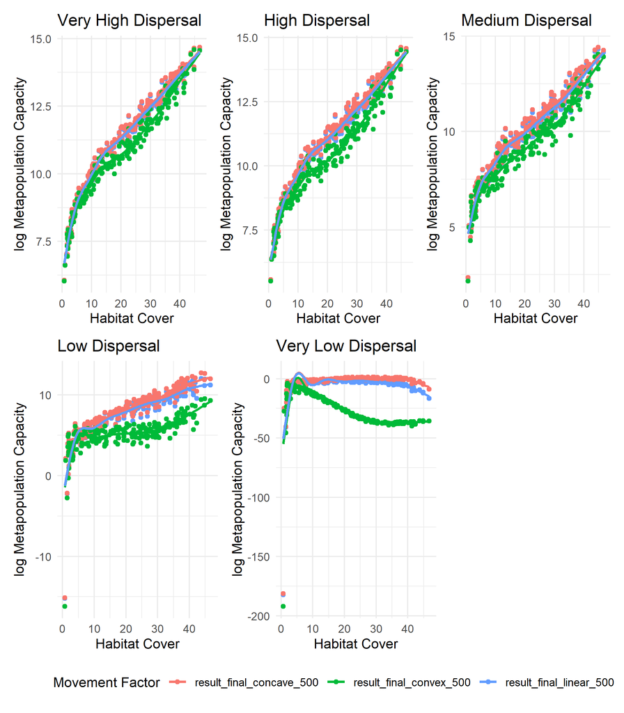

High levels of habitat aggregation with a maximum dispersal distance increase of 5000%

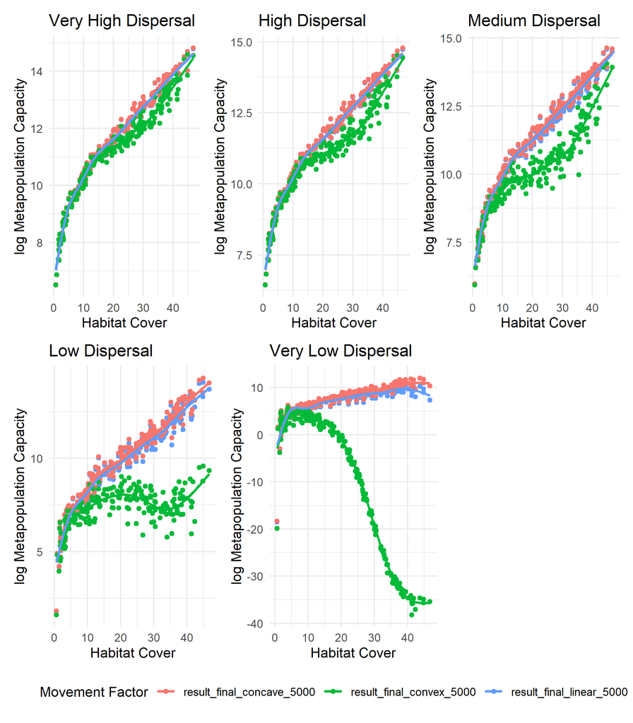

### 2.1.2 Landscapes with medium levels of habitat aggregation

Medium levels of habitat aggregation with a maximum dispersal distance increase of 50%

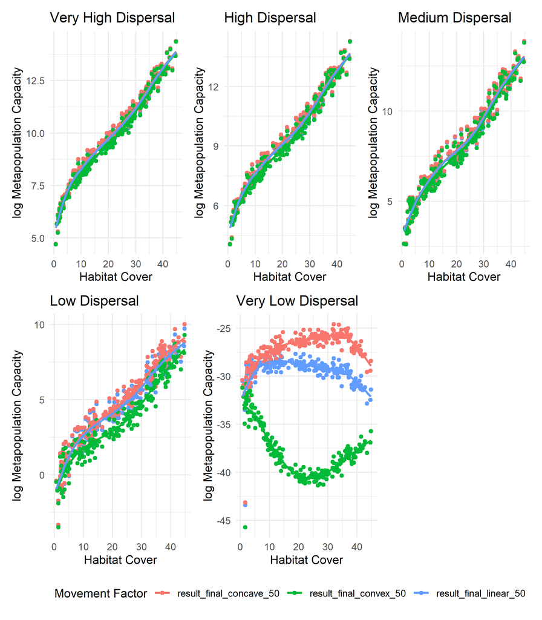

Medium levels of habitat aggregation with a maximum dispersal distance increase of 500%

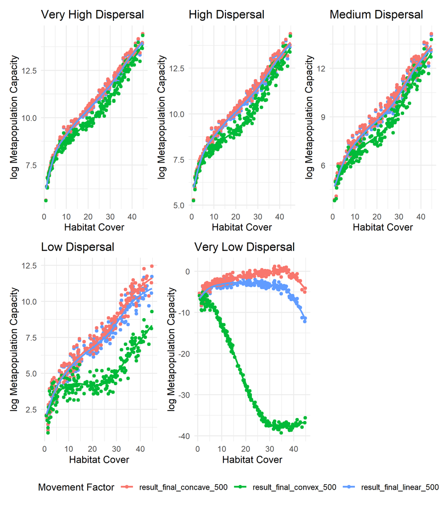

Medium levels of habitat aggregation with a maximum dispersal distance increase of 5000%

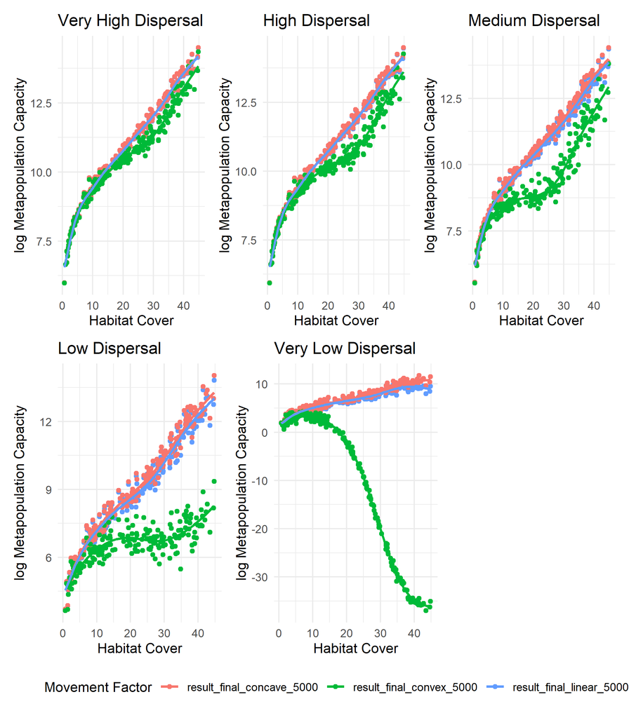

Low levels of habitat aggregation with a maximum dispersal distance increase of 50%

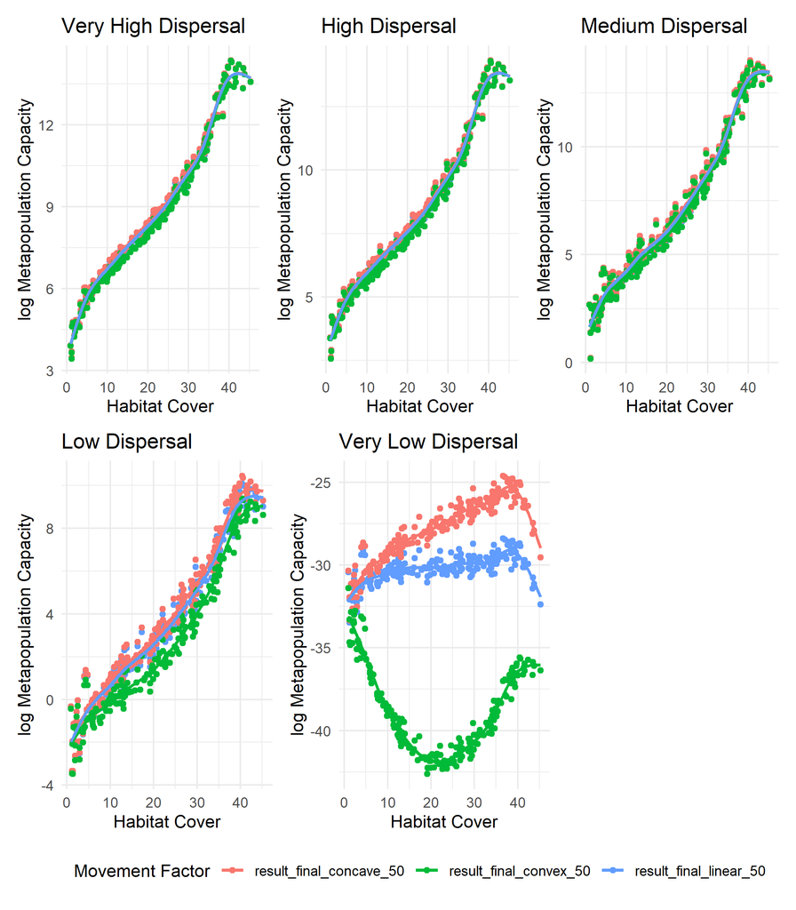

Low levels of habitat aggregation with a maximum dispersal distance increase of 500%

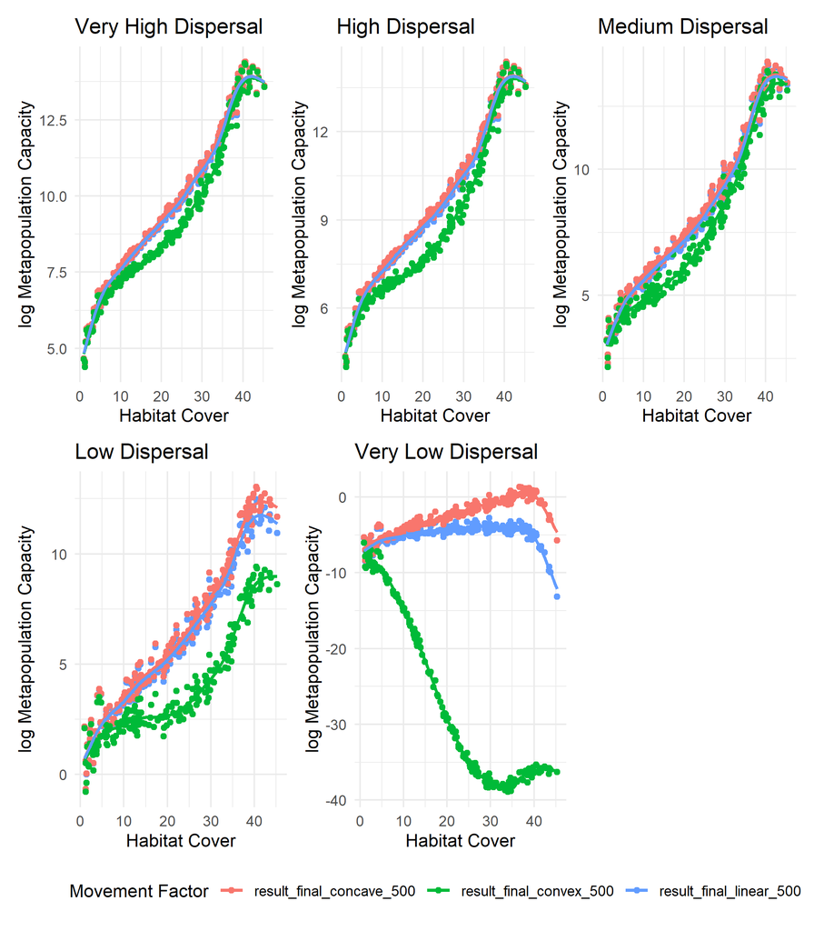

Low levels of habitat aggregation with a maximum dispersal distance increase of 5000%

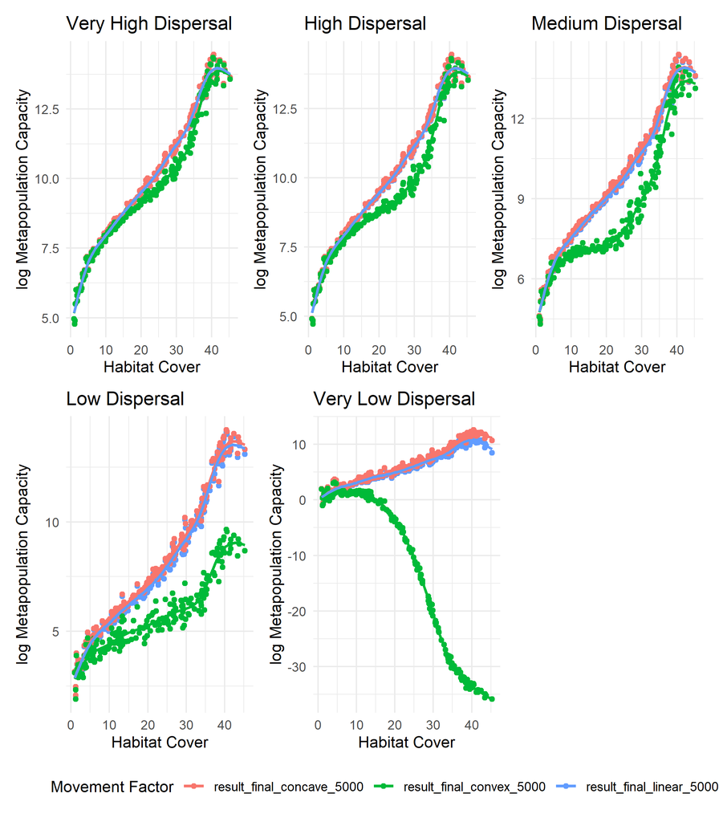

## 2.2 The effect of matrix quality on metapopulation persistence (Medium Colonisation/ Medium Extinction)

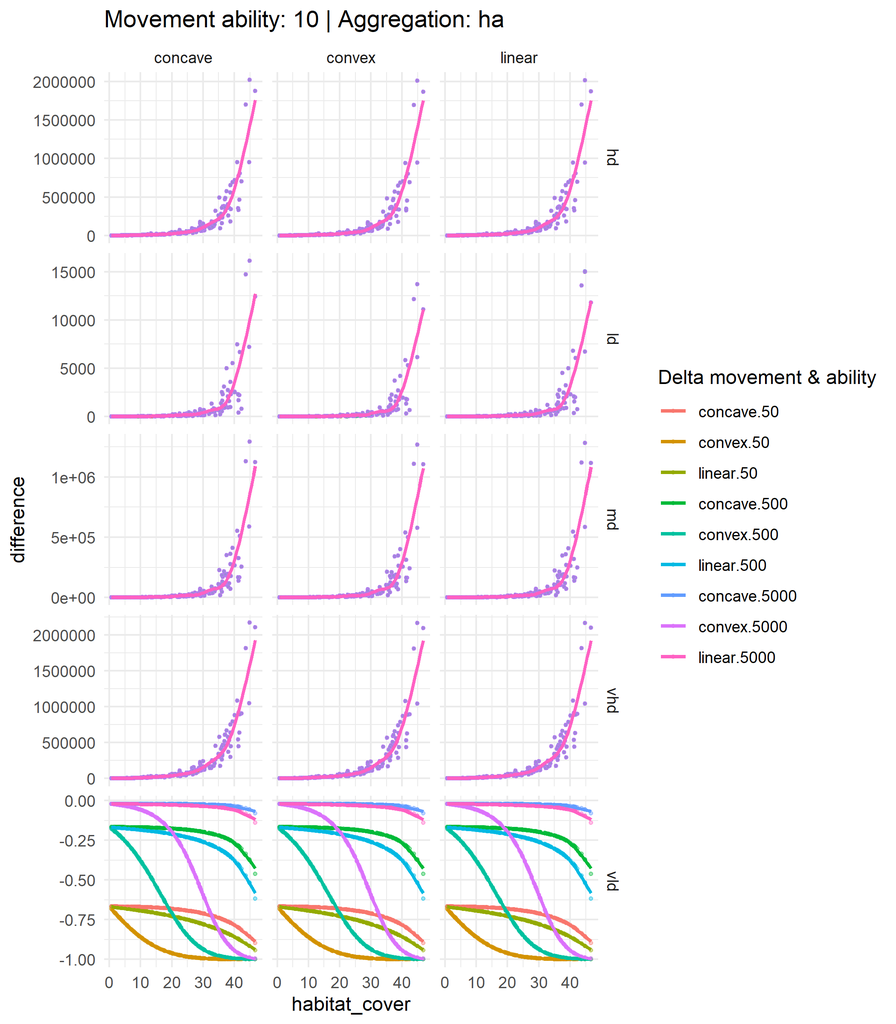

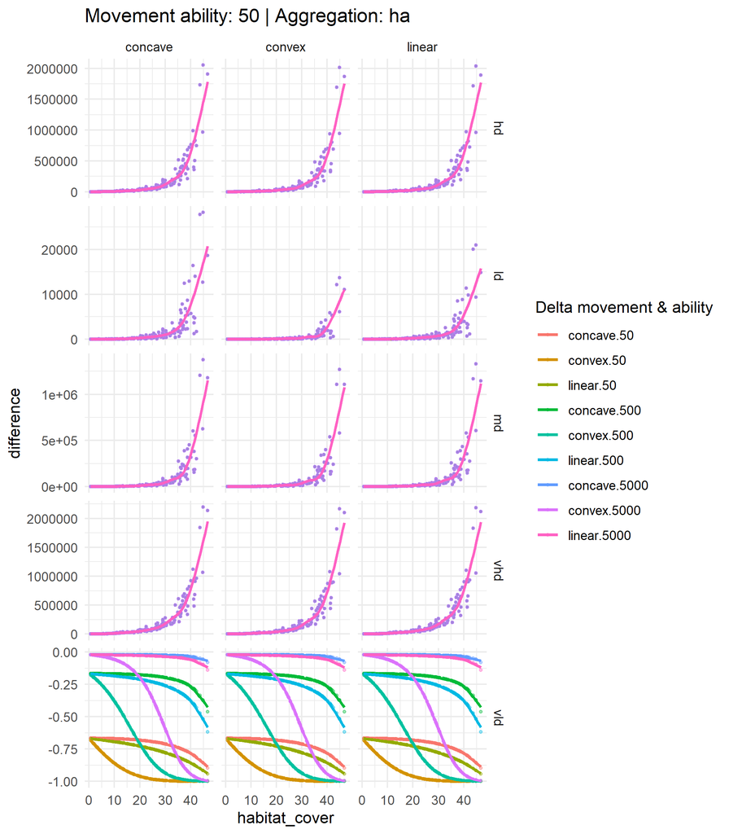

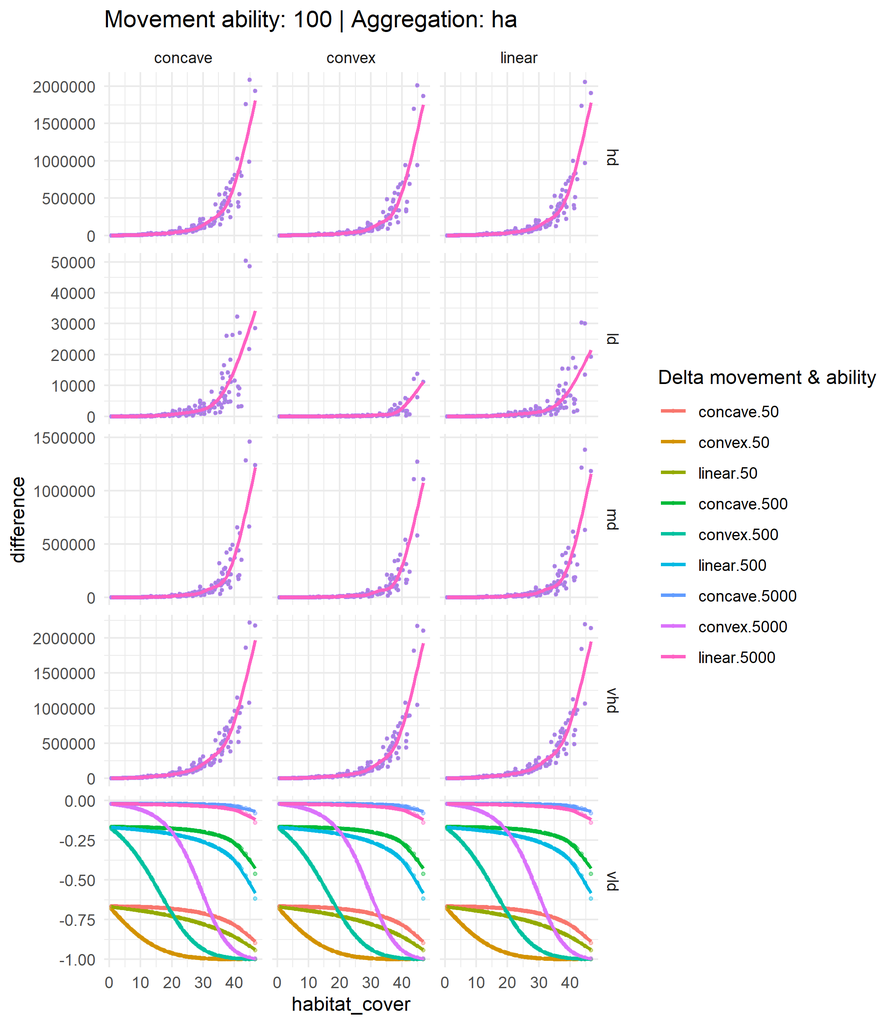

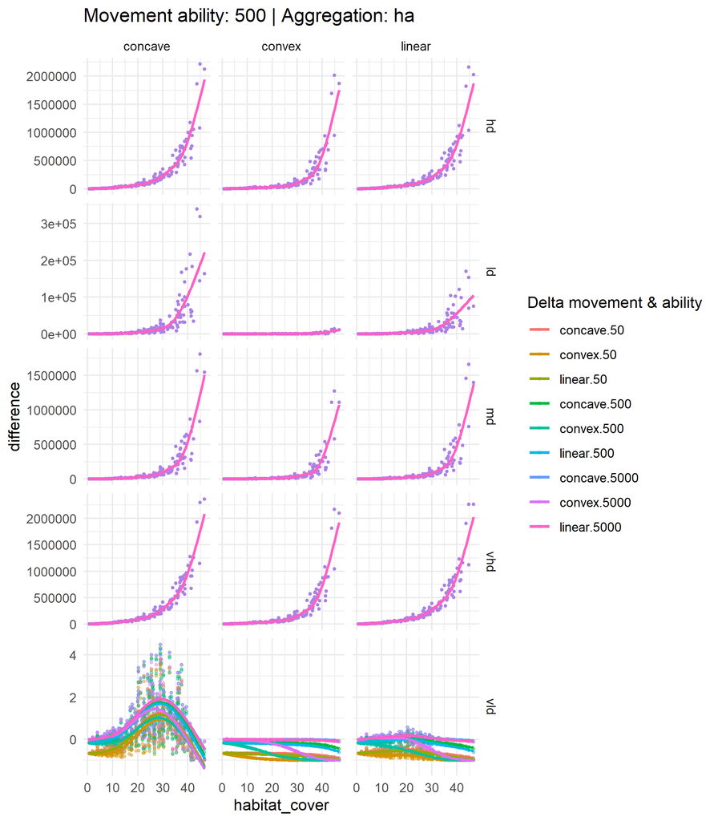

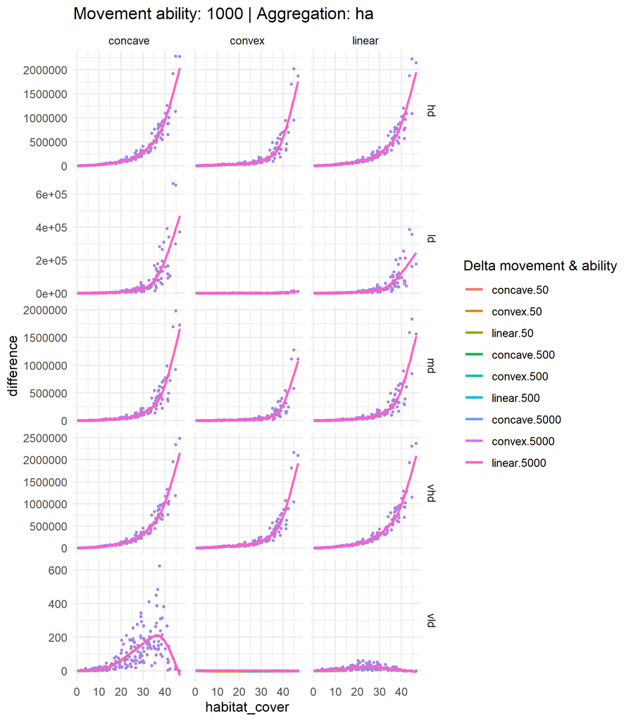

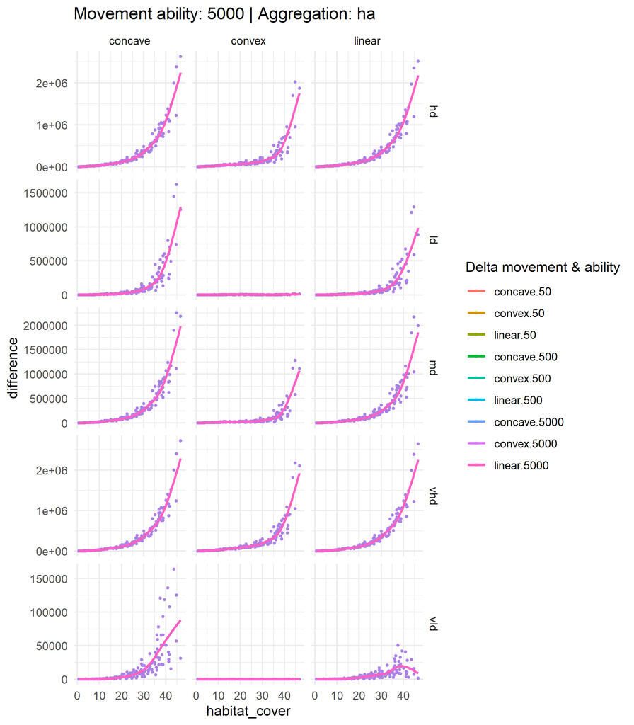

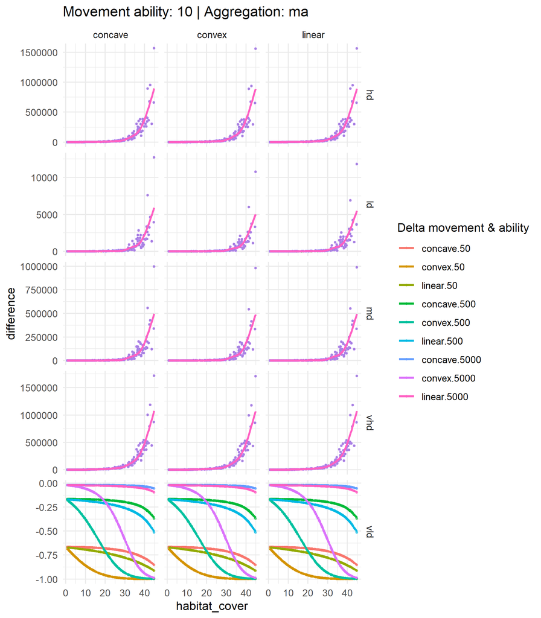

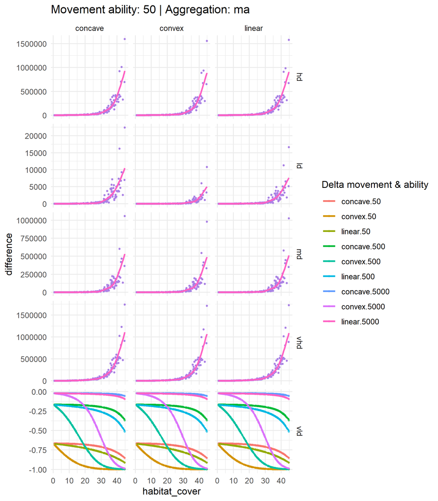

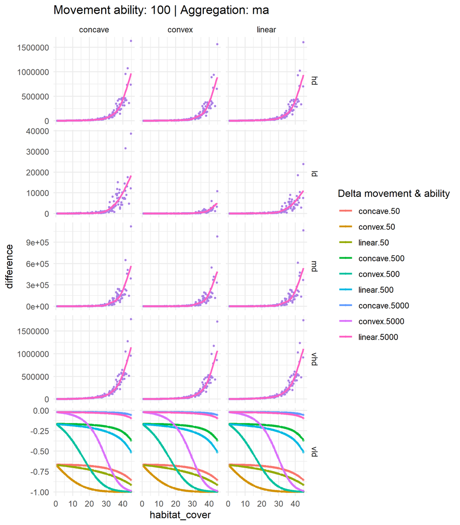

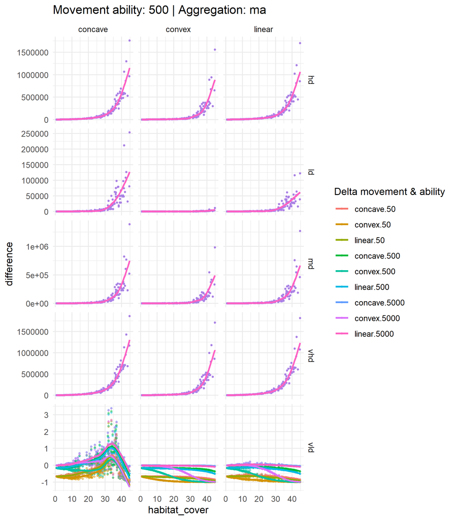

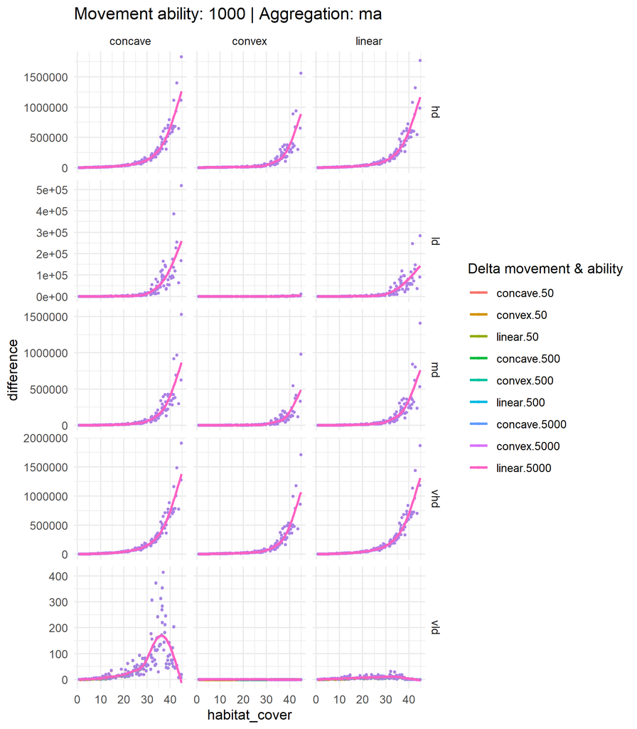

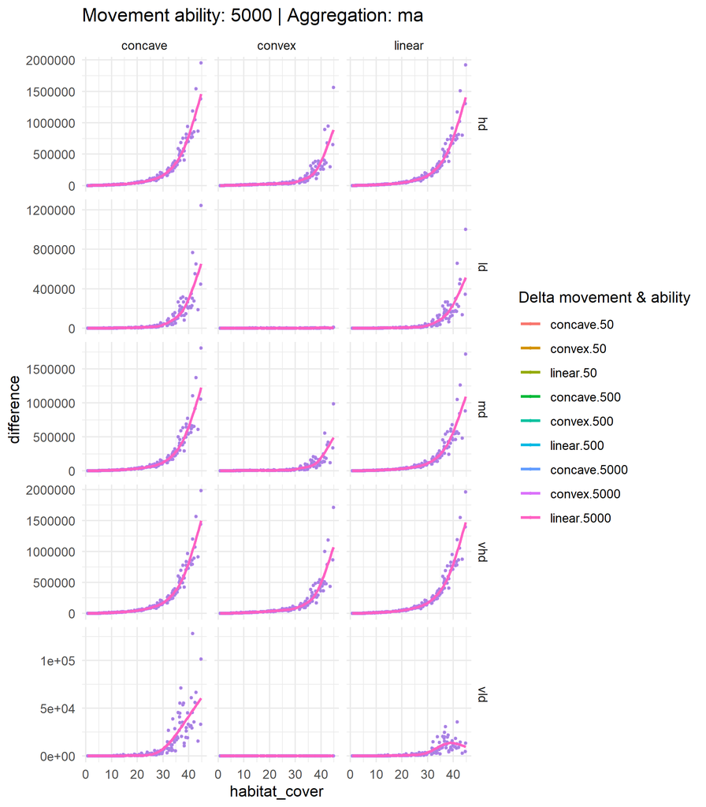

[6 more figures not shown]

## 2.3 The effect of matrix quality on metapopulation persistence (High Colonisation/ Low Extinction)

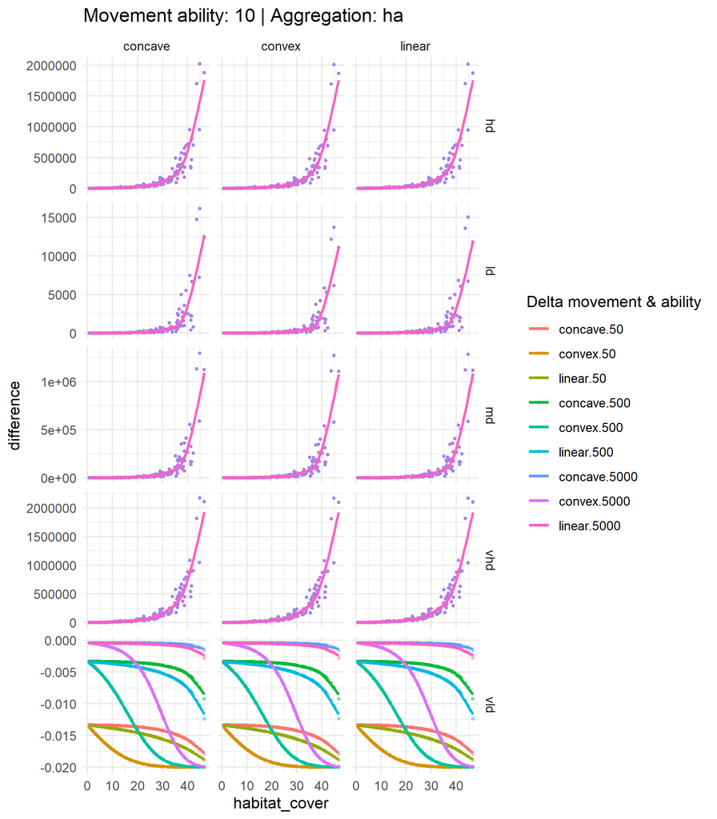

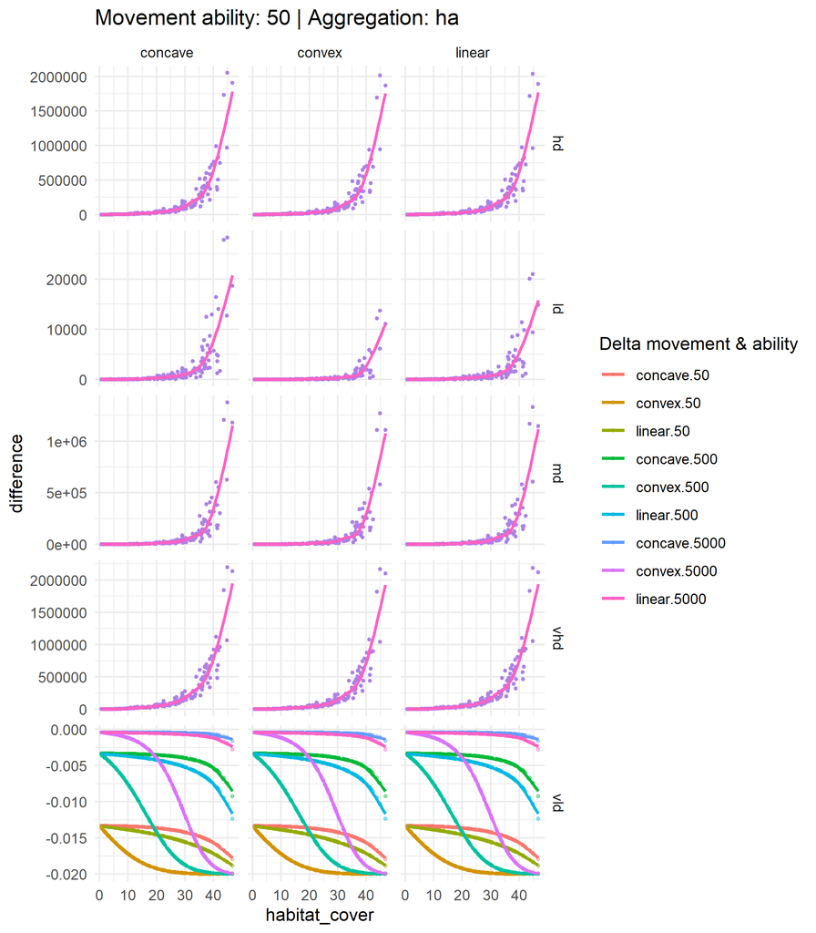

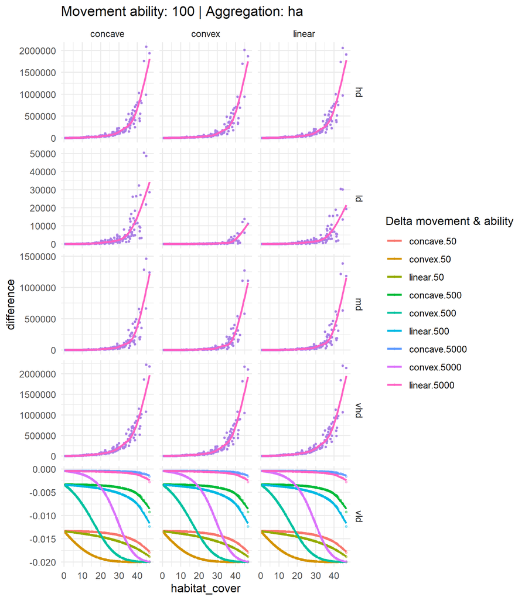

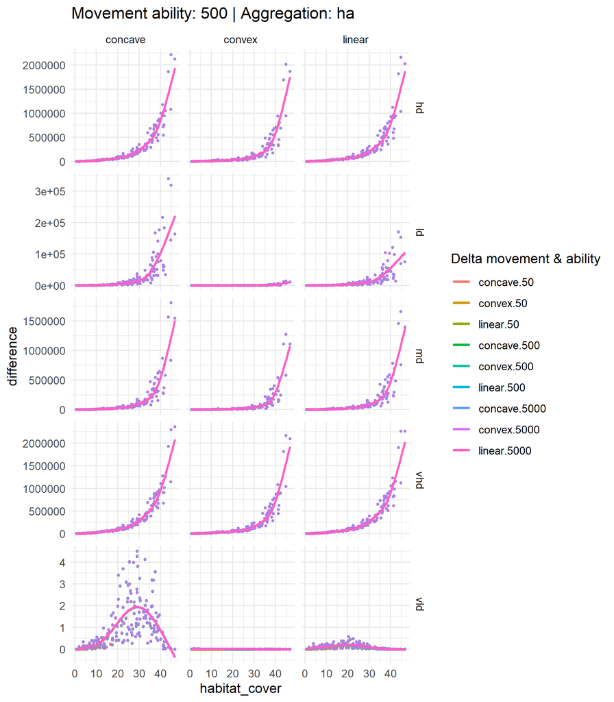